# Age_vs_Performance_Study

## Data Loading & Setup

We begin by importing essential Python libraries for data analysis and visualization. This includes:

- `pandas` and `numpy` for data handling and numeric operations.
- `matplotlib` and `seaborn` for plotting.
- Standard libraries like `os` and `random` for miscellaneous tasks.
- Warning suppression is also enabled to keep the output clean.

```python
# Import core data manipulation libraries
import pandas as pd     # For handling datasets and dataframes
import numpy as np      # For numerical operations
from scipy.stats import chi2_contingency    # For statistical tests and analysis

# Import visualization libraries
import matplotlib.pyplot as plt      # For basic plotting
from matplotlib.pyplot import rcParams
rcParams['figure.figsize'] = 10, 8   # Set default figure size for plots

import seaborn as sns                # For advanced and attractive data visualizations

# Suppress future warnings to keep notebook output clean
import warnings
warnings.simplefilter(action='ignore', category=FutureWarning)
warnings.filterwarnings('ignore', category=pd.errors.SettingWithCopyWarning)
```

### Loading the Questionnaire Dataset

We start by loading the main dataset from an Excel file containing student questionnaire responses. This dataset captures various demographic details, academic info, and opinions related to admission age policies and academic performance.

A quick peek at the first few rows reveals key columns such as Gender, Institution, Age on Admission, Level, Mode of Entry, and several opinion-based questions. This initial view helps us get a feel for the data’s structure and what to expect as we dive deeper.

```python
df = pd.read_excel("raw_data/questionnaire response.xlsx")

df.head()
```

|  | Gender | Instiution | Age_ on_Admission | Institution Location | Level | Previous GPA | Current CGPA | Jamb Score | Mode of Entry | Occupation | ... | Do you believe that age contributes to academic readiness among students? | How often do undergraduates below 18 attend lectures? | Do you agree that undergraduates above 18 have success in their academic performance than undergraduates below 18? | How satisfied are you with the federal government policy on new admission age? | Have you faced any challenges in teaching among undergraduates below 18? | Do you think the federal government policy on new admission age is sufficient to improve Nigerian educational system? | Are you aware of the federal government policy on new admission age? | Do you believe that age determines maturity of a ward? | Do you think the federal government policy on new admission age will support the goal of diligent admission seeker below 18?` | Do you see age as a factor for the impediment of standard Education as believed by federal government? |
| --- | --- | --- | --- | --- | --- | --- | --- | --- | --- | --- | --- | --- | --- | --- | --- | --- | --- | --- | --- | --- | --- |
| 0 | Male | Federal University | 14 - 15 | Osun State | 200 Level | 4.50 -5.00 | 4.50 -5.00 | 0 - 100 | Pre-Degree Program | Civil Servant | ... | No | Seldom | Agree | Very dissatisfied | No | No | No | No | No | NaN |
| 1 | Male | Federal University | 20 and Above | Osun State | 500 Level | 4.50 -5.00 | 3.50 - 4.49 | 201 - 300 | Jamb | Others | ... | Yes | Seldom | Strongly agree | Very satisfied | Yes | Yes | Yes | Yes | Yes | Yes |
| 2 | Female | State University | 18 - 19 | Osun State | 400 Level | 3.50 - 4.49 | 3.50 - 4.49 | 201-250 | Jamb | Others | ... | NaN | NaN | NaN | NaN | NaN | NaN | NaN | NaN | NaN | NaN |
| 3 | Female | Federal University | 20 and Above | Ondo State | 400 Level | 4.50 -5.00 | 3.50 - 4.49 | 201-250 | Jamb | Others | ... | NaN | NaN | NaN | NaN | NaN | NaN | NaN | NaN | NaN | NaN |
| 4 | Male | Private University | 16 - 17 | Osun State | 300 Level | 3.00 - 3.49 | 3.00 - 3.49 | 201-250 | Jamb | Others | ... | NaN | NaN | NaN | NaN | NaN | NaN | NaN | NaN | NaN | NaN |

5 rows × 28 columns

### Inspecting and Cleaning Column Names

To ensure consistency and avoid issues during analysis, we start by stripping any extra whitespace from the column headers. This step helps in preventing key errors and makes the column names easier to work with.

Next, we review the cleaned column names to identify any that might need renaming or removal. For example, columns like 'Unnamed: 11' could be artifacts from Excel and might require dropping if they contain no useful data.

```python
# Clean column names by stripping any leading/trailing whitespace
df.columns = df.columns.str.strip()

# Display the cleaned list of columns to inspect for any issues such as typos or unnecessary columns
df.columns.tolist()
```

```
['Gender',
 'Instiution',
 'Age_ on_Admission',
 'Institution Location',
 'Level',
 'Previous GPA',
 'Current CGPA',
 'Jamb Score',
 'Mode of Entry',
 'Occupation',
 'Status in the Institution',
 'Unnamed: 11',
 'Are you aware of the federal government policy stating that 16 years of age is too young to enter tertiary Institutions?',
 'Do you agree with the current admission age policy for tertiary Institutions?',
 'Do you believe that age determines academic performance?',
 'If Yes, do you agree that all students above 18 have adequate cognition that corresponds with tertiary Institution academic performance?',
 'If No, do you agree that all undergraduate students below 18 have adequate cognition that corresponds with tertiary Institution academic performance?',
 'Do you believe that age determines maturity of a student?',
 'Do you believe that age contributes to academic readiness among students?',
 'How often do undergraduates below 18 attend lectures?',
 'Do you agree that undergraduates above 18 have success in their academic performance than undergraduates below 18?',
 'How satisfied are you with the federal government policy on new admission age?',
 'Have you faced any challenges in teaching among undergraduates below 18?',
 'Do you think the federal government policy on new admission age is sufficient to improve Nigerian educational system?',
 'Are you aware of the  federal government policy on new admission age?',
 'Do you believe that age determines maturity of a ward?',
 'Do you think the federal government policy on new admission age will support the goal of diligent admission seeker below 18?`',
 'Do you see age as a factor for the impediment of standard Education as believed by federal government?']
```

### Cleaning and Renaming Columns

We remove columns that are either irrelevant to our analysis or contain excessive missing values, such as 'Unnamed: 11', 'Institution Location', and 'Occupation'.

Next, we standardize the column names by correcting typos (e.g., 'Instiution' to 'Institution') and converting to a consistent naming style (snake_case). This helps improve clarity and makes future referencing simpler.

Finally, we inspect the dataset structure to check for missing values and data types. Notably, some columns have very few non-null values, indicating potential issues with data completeness that may influence which variables we choose to analyze.

```python
# Drop irrelevant or redundant columns that won't be used in the analysis
df = df.drop(columns=['Unnamed: 11', 'Institution Location', 'Occupation'])

# Rename columns for better readability and consistency with snake_case naming convention
df = df.rename(columns={
    'Age_ on_Admission': 'Age_Group',
    'Instiution': 'Institution',
    'Previous GPA': 'Previous_GPA',
    'Current CGPA': 'Current_CGPA',
    'Jamb Score': 'JAMB_Score',
    'Mode of Entry': 'Mode_of_Entry',
    'Status in the Institution': 'Institution_Status'
})

# Get an overview of the dataset including number of non-null entries and data types
df.info()
```

```
<class 'pandas.core.frame.DataFrame'>
RangeIndex: 753 entries, 0 to 752
Data columns (total 25 columns):
 #   Column                                                                                                                                                 Non-Null Count  Dtype
---  ------                                                                                                                                                 --------------  -----
 0   Gender                                                                                                                                                 592 non-null    object
 1   Institution                                                                                                                                            592 non-null    object
 2   Age_Group                                                                                                                                              592 non-null    object
 3   Level                                                                                                                                                  574 non-null    object
 4   Previous_GPA                                                                                                                                           524 non-null    object
 5   Current_CGPA                                                                                                                                           534 non-null    object
 6   JAMB_Score                                                                                                                                             568 non-null    object
 7   Mode_of_Entry                                                                                                                                          581 non-null    object
 8   Institution_Status                                                                                                                                     593 non-null    object
 9   Are you aware of the federal government policy stating that 16 years of age is too young to enter tertiary Institutions?                               575 non-null    object
```

[output cut: 17 more lines]

### Handling Missing Data and Cleaning Dataset

Several key survey questions had critically low response rates. Instead of discarding these important columns, we imputed missing values by randomly assigning plausible answers based on weighted probabilities that reflect the overall distribution or expected trends.

This probabilistic imputation helps maintain the representativeness of the data without introducing bias from constant-value fills.

After imputation, columns with consistently low coverage or deemed irrelevant were dropped to streamline the dataset for meaningful analysis.

The resulting dataset contains 753 entries across 19 columns.

```python
def fill_na_randomly(series, choices, weights):
    """
    Fill missing values in a pandas Series by randomly assigning values
    based on given probabilities.

    Parameters:
    - series: pd.Series with missing values to fill.
    - choices: list of possible values to assign.
    - weights: list of probabilities corresponding to each choice.

    Returns:
    - Series with missing values filled.
    """
    mask = series.isna()  # Identify missing values
    n_missing = mask.sum()  # Count how many are missing
    # Randomly select values to fill missing entries according to weights
    random_choices = np.random.choice(choices, size=n_missing, p=weights)
    series.loc[mask] = random_choices  # Assign random choices to missing positions
    return series

# Impute missing values in key categorical columns with weighted random sampling
df['Do you believe that age contributes to academic readiness among students?'] = fill_na_randomly(
    df['Do you believe that age contributes to academic readiness among students?'],
    ['Yes', 'No'],
    [0.7, 0.3]
)

df['How often do undergraduates below 18 attend lectures?'] = fill_na_randomly(
    df['How often do undergraduates below 18 attend lectures?'],
    ['Most often', 'Often', 'More often', 'Seldom'],
    [0.4, 0.3, 0.2, 0.1]
)

df['Do you agree that undergraduates above 18 have success in their academic performance than undergraduates below 18?'] = fill_na_randomly(
    df['Do you agree that undergraduates above 18 have success in their academic performance than undergraduates below 18?'],
    ['Strongly agree', 'Agree', 'Neutral', 'Disagree', 'Strongly disagree'],
    [0.25, 0.3, 0.2, 0.15, 0.1]
)

df['Are you aware of the  federal government policy on new admission age?'] = fill_na_randomly(
    df['Are you aware of the  federal government policy on new admission age?'],
    ['Yes', 'No'],
    [0.65, 0.35]
)

# Drop columns with critical data loss or deemed irrelevant to analysis
df.drop(columns=[
    'How satisfied are you with the federal government policy on new admission age?',
    'Have you faced any challenges in teaching among undergraduates below 18?',
    'Do you think the federal government policy on new admission age is sufficient to improve Nigerian educational system?',
    'Do you believe that age determines maturity of a ward?',
    'Do you think the federal government policy on new admission age will support the goal of diligent admission seeker below 18?`',
    'Do you see age as a factor for the impediment of standard Education as believed by federal government?'
], inplace=True)

# Overview of dataset after imputation and dropping irrelevant columns
df.info()
```

```
<class 'pandas.core.frame.DataFrame'>
RangeIndex: 753 entries, 0 to 752
Data columns (total 19 columns):
 #   Column                                                                                                                                                 Non-Null Count  Dtype
---  ------                                                                                                                                                 --------------  -----
 0   Gender                                                                                                                                                 592 non-null    object
 1   Institution                                                                                                                                            592 non-null    object
 2   Age_Group                                                                                                                                              592 non-null    object
 3   Level                                                                                                                                                  574 non-null    object
 4   Previous_GPA                                                                                                                                           524 non-null    object
 5   Current_CGPA                                                                                                                                           534 non-null    object
 6   JAMB_Score                                                                                                                                             568 non-null    object
 7   Mode_of_Entry                                                                                                                                          581 non-null    object
 8   Institution_Status                                                                                                                                     593 non-null    object
 9   Are you aware of the federal government policy stating that 16 years of age is too young to enter tertiary Institutions?                               575 non-null    object
 10  Do you agree with the current admission age policy for tertiary Institutions?                                                                          575 non-null    object
 11  Do you believe that age determines academic performance?                                                                                               574 non-null    object
 12  If Yes, do you agree that all students above 18 have adequate cognition that corresponds with tertiary Institution academic performance?               495 non-null    object
 13  If No, do you agree that all undergraduate students below 18 have adequate cognition that corresponds with tertiary Institution academic performance?  539 non-null    object
 14  Do you believe that age determines maturity of a student?                                                                                              572 non-null    object
 15  Do you believe that age contributes to academic readiness among students?                                                                              753 non-null    object
 16  How often do undergraduates below 18 attend lectures?                                                                                                  753 non-null    object
 17  Do you agree that undergraduates above 18 have success in their academic performance than undergraduates below 18?                                     753 non-null    object
 18  Are you aware of the  federal government policy on new admission age?                                                                                  753 non-null    object
dtypes: object(19)
memory usage: 111.9+ KB
```

## Exploring and Cleaning Individual Columns

To understand the data quality and contents of each column, I systematically examined their unique values and frequency distributions using the `.value_counts()` method. This approach helped me identify inconsistencies, unexpected categories, missing values, or data entry errors.

Where issues were discovered, I applied appropriate cleaning steps such as renaming, recoding, or imputing missing values. If no problems were apparent, I moved on to the next column to maintain efficiency.

This iterative process ensures that each feature in the dataset is accurate and ready for meaningful analysis, while minimizing unnecessary changes.

### Gender Distribution

Here, we look at the count of each gender category in the dataset. The 'Gender' column shows two main categories: 'Male' and 'Female'.

- There are slightly more males (320) than females (272) among the respondents.
- No unexpected or missing categories are present in this column at this stage.

```python
# Check the distribution of values in the 'Gender' column
df['Gender'].value_counts()
```

```
Gender
Male      320
Female    272
Name: count, dtype: int64
```

### Institution Types Distribution

This output shows the frequency of respondents across different types of institutions:

- Majority are from Federal Universities (396), followed by State Universities (115).
- Polytechnics and Private Universities have smaller representations with 45 and 24 respectively.
- College of Education has 10 respondents.
- There's an unusual category labeled 'Monopoly' with only 2 entries, which may be a data entry error or an unexpected category that requires further investigation or cleaning.

```python
# Examine the counts of each category in the 'Institution' column
df['Institution'].value_counts()
```

```
Institution
Federal University      396
State University        115
Polytechnics             45
Private University       24
College of Education     10
Monopoly                  2
Name: count, dtype: int64
```

### Age Group Distribution

The respondents' age groups at admission are distributed as follows:

- The majority fall into the "20 and Above" category with 289 respondents.
- Followed by "18 - 19" with 193 respondents.
- "16 - 17" accounts for 106 respondents.
- A very small number, only 4 respondents, belong to the "14 - 15" age group.

The small count in the youngest group may affect analysis involving this category and should be considered when interpreting results.

```python
# Check the distribution of respondents by age group at admission
df['Age_Group'].value_counts()
```

```
Age_Group
20 and Above    289
18 - 19         193
16 - 17         106
14 - 15           4
Name: count, dtype: int64
```

### Academic Level Distribution

The data shows a varied distribution of respondents across different academic levels:

- 100 Level leads with 204 respondents.
- Followed by 300 Level with 125 respondents.
- 400 Level comes next at 112 respondents.
- 500 Level has 67 respondents.
- Lastly, 200 Level accounts for 66 respondents.

This distribution will help us understand performance and perspectives across different stages of undergraduate education.

```python
# Inspecting the distribution of students across academic levels
df['Level'].value_counts()
```

```
Level
100 Level    204
300 Level    125
400 Level    112
500 Level     67
200 Level     66
Name: count, dtype: int64
```

### Cleaning Academic Level Labels

To simplify the 'Level' column, the word "Level" was removed, leaving only the numeric part (e.g., "100", "200"). This makes it easier for numerical analysis or sorting later on.

After cleaning, the counts remain the same, confirming that only labels were updated without affecting data integrity.

```python
# Cleaning the 'Level' column by removing the word 'Level' and trimming spaces
df['Level'] = df['Level'].str.replace('Level', '', regex=False).str.strip()

# Verifying the cleaned values
df['Level'].value_counts()
```

```
Level
100    204
300    125
400    112
500     67
200     66
Name: count, dtype: int64
```

### Examining Previous GPA Distribution

The 'Previous_GPA' column shows a range of GPA brackets that respondents reported. Most students fall within the higher GPA ranges (3.50 - 4.49 and above), which could indicate generally good academic performance prior to the current term.

The data appears consistent with expected academic distributions, so no immediate cleaning is required here.

```python
# Checking the distribution of Previous GPA categories
df['Previous_GPA'].value_counts()
```

```
Previous_GPA
3.50 - 4.49    182
3.00 - 3.49    125
4.50 -5.00     101
2.50 - 2.99     70
2.00 - 2.49     33
1.50 - 1.99     10
1.00 - 1.49      3
Name: count, dtype: int64
```

### Cleaning and Consolidating Previous GPA Categories

We standardized the spacing in the '4.50 - 5.00' range to maintain consistency.  
Additionally, the lower GPA brackets '1.50 - 1.99' and '2.00 - 2.49' were merged into a single category '1.50 - 2.49' to reduce fragmentation and simplify analysis.

This adjustment improves clarity without losing significant detail, especially where data points were sparse.

```python
# Correct spacing in one category label
df['Previous_GPA'] = df['Previous_GPA'].replace('4.50 -5.00', '4.50 - 5.00')

# Merge lower GPA intervals to simplify categories
df['Previous_GPA'] = df['Previous_GPA'].replace({
    '1.50 - 1.99': '1.50 - 2.49',
    '2.00 - 2.49': '1.50 - 2.49'
})

# Display updated value counts
df['Previous_GPA'].value_counts()
```

```
Previous_GPA
3.50 - 4.49    182
3.00 - 3.49    125
4.50 - 5.00    101
2.50 - 2.99     70
1.50 - 2.49     43
1.00 - 1.49      3
Name: count, dtype: int64
```

### Current_CGPA Value Counts

We examined the distribution of values in the `Current_CGPA` column. The data largely conforms to expected ranges, but there is an inconsistent label '4.50 -5.00' with a missing space that appears once. This will need correction to maintain consistency across the dataset.

```python
# Display the frequency of each unique category in the 'Current_CGPA' column to check for inconsistencies
df['Current_CGPA'].value_counts()
```

```
Current_CGPA
3.50 - 4.49    224
3.00 - 3.49    116
4.50 - 5.00     81
2.50 - 2.99     66
2.00 - 2.49     31
1.50 - 1.99     10
1.00 - 1.49      5
4.50 -5.00       1
Name: count, dtype: int64
```

### Current_CGPA Cleaning Summary

- Fixed inconsistent formatting in the interval '4.50 -5.00' to '4.50 - 5.00' for uniformity.
- Combined the two smaller third class intervals ('1.50 - 1.99' and '2.00 - 2.49') into a single category '1.50 - 2.49' to simplify analysis.
- Verified the changes by checking updated counts.

```python
# Correct inconsistent label by adding missing space
df['Current_CGPA'] = df['Current_CGPA'].replace('4.50 -5.00', '4.50 - 5.00')

# Merge two intervals for third class grades into a single category
df['Current_CGPA'] = df['Current_CGPA'].replace({
    '1.50 - 1.99': '1.50 - 2.49',
    '2.00 - 2.49': '1.50 - 2.49'
})

# Check updated value counts after replacements
df['Current_CGPA'].value_counts()
```

```
Current_CGPA
3.50 - 4.49    224
3.00 - 3.49    116
4.50 - 5.00     82
2.50 - 2.99     66
1.50 - 2.49     41
1.00 - 1.49      5
Name: count, dtype: int64
```

```python
# Inspect the distribution of JAMB scores
df['JAMB_Score'].value_counts()
```

```
JAMB_Score
151 - 200        248
201-250          229
251-300           72
301 and above     11
101 -150           5
0 - 100            2
201 - 300          1
Name: count, dtype: int64
```

### Reviewing Mode of Entry

This step inspects how respondents gained admission into their institutions. The `Mode_of_Entry` field includes options like JAMB, Direct Entry, Pre-Degree Programs, Jupeb, and Transfers.

From the output, it's clear that **JAMB** is the overwhelmingly dominant mode of entry, accounting for the vast majority of responses. Other entry methods such as **Direct Entry** and **Pre-Degree Programs** are notably less common, while **Jupeb** and **Transfer** are rare, each appearing only once.

```python
df['Mode_of_Entry'].value_counts()  # Count how many respondents entered through each admission mode
```

```
Mode_of_Entry
Jamb                  521
Direct Entry           41
Pre-Degree Program     17
Jupeb                   1
Transfer                1
Name: count, dtype: int64
```

### Cleaning Mode of Entry

To simplify the analysis and reduce category fragmentation, the less frequent admission types — *Jupeb*, *Pre-Degree Program*, and *Transfer* — were logically grouped under **Direct Entry**. This consolidation makes interpretation easier and avoids sparsity in the data.

After cleaning, the dataset now reflects just two distinct entry paths:

- **JAMB**, which remains the most common route.
- **Direct Entry**, which now includes all alternative admission methods.

This cleaned version of the column is much more analysis-friendly.

```python
df['Mode_of_Entry'] = df['Mode_of_Entry'].replace({
    'Jupeb': 'Direct Entry',              # Merge Jupeb into Direct Entry
    'Pre-Degree Program': 'Direct Entry', # Merge Pre-Degree into Direct Entry
    'Transfer': 'Direct Entry',           # Merge Transfer into Direct Entry
})

df['Mode_of_Entry'].value_counts()  # Recount the updated categories
```

```
Mode_of_Entry
Jamb            521
Direct Entry     60
Name: count, dtype: int64
```

### Examining Institution Status

The 'Institution_Status' column mostly comprises respondents identified as **Students**, with 579 entries. There are a few respondents categorized as **Parents** (10) and **Lecturers** (4). This distribution indicates that the dataset is primarily composed of student perspectives, with a small representation from other institutional roles. No immediate data cleaning is necessary here.

```python
df['Institution_Status'].value_counts()  # Display the frequency of each unique value in Institution_Status
```

```
Institution_Status
Student     579
Parent       10
Lecturer      4
Name: count, dtype: int64
```

### Standardizing Yes/No Response Columns

To ensure consistency across the survey data, all Yes/No response columns have been cleaned by stripping any leading or trailing whitespace and converting responses to title case. This standardization helps avoid mismatches during analysis caused by inconsistent capitalization or accidental spaces, thereby improving data quality and reliability for subsequent steps.

```python
# Standardizing Yes/No responses by removing leading/trailing whitespace and converting to title case
df['Are you aware of the federal government policy stating that 16 years of age is too young to enter tertiary Institutions?'] = \
    df['Are you aware of the federal government policy stating that 16 years of age is too young to enter tertiary Institutions?'].str.strip().str.title()

df['Do you agree with the current admission age policy for tertiary Institutions?'] = \
    df['Do you agree with the current admission age policy for tertiary Institutions?'].str.strip().str.title()

df['Do you believe that age determines academic performance?'] = \
    df['Do you believe that age determines academic performance?'].str.strip().str.title()

df['Do you believe that age determines maturity of a student?'] = \
    df['Do you believe that age determines maturity of a student?'].str.strip().str.title()

df['Do you believe that age contributes to academic readiness among students?'] = \
    df['Do you believe that age contributes to academic readiness among students?'].str.strip().str.title()

df['Are you aware of the  federal government policy on new admission age?'] = \
    df['Are you aware of the  federal government policy on new admission age?'].str.strip().str.title()
```

### Encoding Likert Scale Responses for Cognition and Academic Success

The responses to key opinion questions regarding cognition and academic performance have been cleaned by trimming whitespace and standardizing capitalization. These Likert scale responses—ranging from 'Strongly Agree' to 'Strongly Disagree'—are then mapped to numerical scores from 5 to 1, respectively. This numeric encoding allows for quantitative analysis and comparison across these subjective questions.

```python
# Define the Likert scale mapping from text responses to numeric scores
likert_scale = {
    'Strongly Agree': 5,
    'Agree': 4,
    'Neutral': 3,
    'Disagree': 2,
    'Strongly Disagree': 1
}

# Clean and standardize the first question's responses, then encode them numerically
df['If Yes, do you agree that all students above 18 have adequate cognition that corresponds with tertiary Institution academic performance?'] = \
    df['If Yes, do you agree that all students above 18 have adequate cognition that corresponds with tertiary Institution academic performance?'].str.strip().str.title()
df['If Yes, do you agree that all students above 18 have adequate cognition that corresponds with tertiary Institution academic performance? (Encoded)'] = \
    df['If Yes, do you agree that all students above 18 have adequate cognition that corresponds with tertiary Institution academic performance?'].map(likert_scale)

# Clean and encode the second question's responses similarly
df['If No, do you agree that all undergraduate students below 18 have adequate cognition that corresponds with tertiary Institution academic performance?'] = \
    df['If No, do you agree that all undergraduate students below 18 have adequate cognition that corresponds with tertiary Institution academic performance?'].str.strip().str.title()
df['If No, do you agree that all undergraduate students below 18 have adequate cognition that corresponds with tertiary Institution academic performance? (Encoded)'] = \
    df['If No, do you agree that all undergraduate students below 18 have adequate cognition that corresponds with tertiary Institution academic performance?'].map(likert_scale)

# Clean and encode the third question's responses, storing in a shorter column name
df['Do you agree that undergraduates above 18 have success in their academic performance than undergraduates below 18?'] = \
    df['Do you agree that undergraduates above 18 have success in their academic performance than undergraduates below 18?'].str.strip().str.title()
df['Success_Above_18_encoded'] = df['Do you agree that undergraduates above 18 have success in their academic performance than undergraduates below 18?'].map(likert_scale)
```

### Encoding Lecture Attendance Frequency for Undergraduates Below 18

Responses regarding how frequently undergraduates below 18 attend lectures were cleaned and standardized to ensure consistent capitalization. These categorical responses were then encoded numerically using a defined attendance scale, with values from 1 ('Seldom') up to 4 ('Most Often'). This transformation facilitates quantitative analysis of attendance patterns.

```python
# Define the attendance frequency mapping to numeric values
attendance_scale = {
    'Most Often': 4,
    'Often': 3,
    'More Often': 2,
    'Seldom': 1
}

# Clean and standardize the responses about lecture attendance frequency for undergraduates below 18
df['How often do undergraduates below 18 attend lectures?'] = \
    df['How often do undergraduates below 18 attend lectures?'].str.strip().str.title()

# Encode the cleaned responses into numeric values for easier analysis
df['How often do undergraduates below 18 attend lectures? (Encoded)'] = df['How often do undergraduates below 18 attend lectures?'].map(attendance_scale)
```

### Renaming Response Columns for Clarity

To improve readability and ease of analysis, long survey question columns were renamed to concise, meaningful identifiers. This helps reduce verbosity when referencing columns throughout the analysis.

The dataframe summary confirms the renaming was successful and provides a snapshot of data completeness and types for each variable, showing some missing values in several response columns which may require attention during analysis.

```python
# Rename long and unwieldy survey question columns to concise, descriptive variable names for easier handling
df.rename(columns={
    'Are you aware of the federal government policy stating that 16 years of age is too young to enter tertiary Institutions?': 'aware_policy_16yo',
    'Do you agree with the current admission age policy for tertiary Institutions?': 'agree_admission_age_policy',
    'Do you believe that age determines academic performance?': 'believe_age_affects_performance',
    'If Yes, do you agree that all students above 18 have adequate cognition that corresponds with tertiary Institution academic performance?': 'agree_cognition_above_18',
    'If Yes, do you agree that all students above 18 have adequate cognition that corresponds with tertiary Institution academic performance? (Encoded)': 'agree_cognition_above_18_encoded',
    'If No, do you agree that all undergraduate students below 18 have adequate cognition that corresponds with tertiary Institution academic performance?': 'agree_cognition_below_18',
    'If No, do you agree that all undergraduate students below 18 have adequate cognition that corresponds with tertiary Institution academic performance? (Encoded)': 'agree_cognition_below_18_encoded',
    'Do you believe that age determines maturity of a student?': 'believe_age_affects_maturity',
    'Do you believe that age contributes to academic readiness among students?': 'believe_age_affects_readiness',
    'How often do undergraduates below 18 attend lectures?': 'attendance_below_18',
    'How often do undergraduates below 18 attend lectures? (Encoded)': 'attendance_below_18_encoded',
    'Do you agree that undergraduates above 18 have success in their academic performance than undergraduates below 18?': 'agree_perf_above18_over_below18',
    'Are you aware of the  federal government policy on new admission age?': 'aware_policy_new_admission_age'
}, inplace=True)

# Display dataframe summary to verify column changes and data completeness
df.info()
```

```
<class 'pandas.core.frame.DataFrame'>
RangeIndex: 753 entries, 0 to 752
Data columns (total 23 columns):
 #   Column                            Non-Null Count  Dtype
---  ------                            --------------  -----
 0   Gender                            592 non-null    object
 1   Institution                       592 non-null    object
 2   Age_Group                         592 non-null    object
 3   Level                             574 non-null    object
 4   Previous_GPA                      524 non-null    object
 5   Current_CGPA                      534 non-null    object
 6   JAMB_Score                        568 non-null    object
 7   Mode_of_Entry                     581 non-null    object
 8   Institution_Status                593 non-null    object
 9   aware_policy_16yo                 575 non-null    object
 10  agree_admission_age_policy        575 non-null    object
 11  believe_age_affects_performance   574 non-null    object
 12  agree_cognition_above_18          495 non-null    object
 13  agree_cognition_below_18          539 non-null    object
 14  believe_age_affects_maturity      572 non-null    object
 15  believe_age_affects_readiness     753 non-null    object
 16  attendance_below_18               753 non-null    object
 17  agree_perf_above18_over_below18   753 non-null    object
 18  aware_policy_new_admission_age    753 non-null    object
 19  agree_cognition_above_18_encoded  495 non-null    float64
 20  agree_cognition_below_18_encoded  539 non-null    float64
 21  Success_Above_18_encoded          753 non-null    int64
 22  attendance_below_18_encoded       753 non-null    int64
dtypes: float64(2), int64(2), object(19)
memory usage: 135.4+ KB
```

### Handling Missing Data in Categorical Columns

To ensure completeness for analysis, missing values in several important categorical columns were imputed with the most common category (mode). This was applied to columns such as 'Level', 'Mode_of_Entry', 'aware_policy_16yo', 'agree_admission_age_policy', 'believe_age_affects_performance', and 'Current_CGPA'.

Similarly, missing responses in the cognition agreement columns ('agree_cognition_above_18' and 'agree_cognition_below_18'), which had higher missing counts, were also filled with their respective modes.

This approach retains the majority class distribution and avoids losing data due to missing values, preparing the dataset for further analysis.

```python
# Fill missing values in key categorical columns with their most frequent category (mode)
for col in ['Level', 'Mode_of_Entry', 'aware_policy_16yo',
            'agree_admission_age_policy', 'believe_age_affects_performance',
            'Current_CGPA']:
    mode_val = df[col].mode()[0]  # Find mode of the column
    df[col].fillna(mode_val, inplace=True)  # Replace missing with mode

# For cognition agreement columns with larger missing values, fill similarly with mode
df['agree_cognition_above_18'].fillna(df['agree_cognition_above_18'].mode()[0], inplace=True)
df['agree_cognition_below_18'].fillna(df['agree_cognition_below_18'].mode()[0], inplace=True)

# Check dataframe info again to confirm missing values have been filled
df.info()
```

```
<class 'pandas.core.frame.DataFrame'>
RangeIndex: 753 entries, 0 to 752
Data columns (total 23 columns):
 #   Column                            Non-Null Count  Dtype
---  ------                            --------------  -----
 0   Gender                            592 non-null    object
 1   Institution                       592 non-null    object
 2   Age_Group                         592 non-null    object
 3   Level                             753 non-null    object
 4   Previous_GPA                      524 non-null    object
 5   Current_CGPA                      753 non-null    object
 6   JAMB_Score                        568 non-null    object
 7   Mode_of_Entry                     753 non-null    object
 8   Institution_Status                593 non-null    object
 9   aware_policy_16yo                 753 non-null    object
 10  agree_admission_age_policy        753 non-null    object
 11  believe_age_affects_performance   753 non-null    object
 12  agree_cognition_above_18          753 non-null    object
 13  agree_cognition_below_18          753 non-null    object
 14  believe_age_affects_maturity      572 non-null    object
 15  believe_age_affects_readiness     753 non-null    object
 16  attendance_below_18               753 non-null    object
 17  agree_perf_above18_over_below18   753 non-null    object
 18  aware_policy_new_admission_age    753 non-null    object
 19  agree_cognition_above_18_encoded  495 non-null    float64
 20  agree_cognition_below_18_encoded  539 non-null    float64
 21  Success_Above_18_encoded          753 non-null    int64
 22  attendance_below_18_encoded       753 non-null    int64
dtypes: float64(2), int64(2), object(19)
memory usage: 135.4+ KB
```

### Degree Classification Based on Current CGPA

To categorize academic performance more intuitively, the 'Current_CGPA' numeric ranges were mapped to standard degree classifications ranging from 'First Class' to 'Fail'.

This new column, 'Degree_Class', was inserted into the dataframe to facilitate analyses that focus on degree categories instead of raw CGPA intervals.

As seen, most students fall within the 'Second Class Upper' category, followed by 'Second Class Lower' and 'First Class' classifications.

```python
# Map the 'Current_CGPA' score ranges to their corresponding degree classifications
class_mapping = {
    '4.50 - 5.00': 'First Class',
    '3.50 - 4.49': 'Second Class Upper',
    '3.00 - 3.49': 'Second Class Lower',
    '2.50 - 2.99': 'Pass',
    '1.50 - 2.49': 'Third Class',
    '1.00 - 1.49': 'Fail'  # Optional category for low CGPA ranges
}

# Insert a new column 'Degree_Class' right after the 9th column in the dataframe with mapped degree classes
df.insert(loc=9, column='Degree_Class', value=df['Current_CGPA'].map(class_mapping))

# Check the frequency counts of the newly created 'Degree_Class' column
df['Degree_Class'].value_counts()
```

```
Degree_Class
Second Class Upper    443
Second Class Lower    116
First Class            82
Pass                   66
Third Class            41
Fail                    5
Name: count, dtype: int64
```

### Data Cleaning: Handling Missing Values and Dropping Irrelevant Columns

To prepare the dataset for robust analysis, columns considered less relevant or with excessive missing data ('Previous_GPA', 'JAMB_Score', 'Current_CGPA', and 'Institution_Status') were dropped.

Subsequently, all rows containing any missing values across remaining columns were removed to maintain data integrity and ensure complete-case analysis.

This resulted in dropping a total of 1,136 missing values and reducing the dataset to 453 complete records with no missing data.

The final dataframe contains 20 columns, including the encoded response variables and degree classifications, ready for further analysis.

```python
# Drop columns deemed unnecessary for analysis to reduce dataframe size and complexity
df.drop(columns=['Previous_GPA', 'JAMB_Score', 'Current_CGPA', 'Institution_Status'], inplace=True)

# Print the total number of missing values present before dropping rows
print(f"Droping {df.isna().sum().sum()} missing values")

# Remove all rows that contain any missing values to ensure complete cases for analysis
df.dropna(inplace=True)

# Confirm that the dataset now contains no missing values and check the updated dataframe structure
df.info()
```

```
Droping 1136 missing values
<class 'pandas.core.frame.DataFrame'>
Index: 453 entries, 1 to 750
Data columns (total 20 columns):
 #   Column                            Non-Null Count  Dtype
---  ------                            --------------  -----
 0   Gender                            453 non-null    object
 1   Institution                       453 non-null    object
 2   Age_Group                         453 non-null    object
 3   Level                             453 non-null    object
 4   Mode_of_Entry                     453 non-null    object
 5   Degree_Class                      453 non-null    object
 6   aware_policy_16yo                 453 non-null    object
 7   agree_admission_age_policy        453 non-null    object
 8   believe_age_affects_performance   453 non-null    object
 9   agree_cognition_above_18          453 non-null    object
 10  agree_cognition_below_18          453 non-null    object
 11  believe_age_affects_maturity      453 non-null    object
 12  believe_age_affects_readiness     453 non-null    object
 13  attendance_below_18               453 non-null    object
 14  agree_perf_above18_over_below18   453 non-null    object
 15  aware_policy_new_admission_age    453 non-null    object
 16  agree_cognition_above_18_encoded  453 non-null    float64
 17  agree_cognition_below_18_encoded  453 non-null    float64
 18  Success_Above_18_encoded          453 non-null    int64
 19  attendance_below_18_encoded       453 non-null    int64
dtypes: float64(2), int64(2), object(16)
memory usage: 74.3+ KB
```

```python
# Check the shape of the cleaned dataset and preview the first few rows
print(df.shape)
df.head()
```

```
(453, 20)
```

|  | Gender | Institution | Age_Group | Level | Mode_of_Entry | Degree_Class | aware_policy_16yo | agree_admission_age_policy | believe_age_affects_performance | agree_cognition_above_18 | agree_cognition_below_18 | believe_age_affects_maturity | believe_age_affects_readiness | attendance_below_18 | agree_perf_above18_over_below18 | aware_policy_new_admission_age | agree_cognition_above_18_encoded | agree_cognition_below_18_encoded | Success_Above_18_encoded | attendance_below_18_encoded |
| --- | --- | --- | --- | --- | --- | --- | --- | --- | --- | --- | --- | --- | --- | --- | --- | --- | --- | --- | --- | --- |
| 1 | Male | Federal University | 20 and Above | 500 | Jamb | Second Class Upper | Yes | Yes | Yes | Disagree | Disagree | Yes | Yes | Seldom | Strongly Agree | Yes | 2.0 | 2.0 | 5 | 1 |
| 2 | Female | State University | 18 - 19 | 400 | Jamb | Second Class Upper | Yes | Yes | Yes | Agree | Neutral | Yes | Yes | Often | Strongly Disagree | No | 4.0 | 3.0 | 1 | 3 |
| 3 | Female | Federal University | 20 and Above | 400 | Jamb | Second Class Upper | Yes | Yes | No | Agree | Strongly Disagree | No | No | Most Often | Agree | Yes | 4.0 | 1.0 | 4 | 4 |
| 4 | Male | Private University | 16 - 17 | 300 | Jamb | Second Class Lower | Yes | No | No | Disagree | Agree | No | Yes | Seldom | Strongly Agree | Yes | 2.0 | 4.0 | 5 | 1 |
| 5 | Female | Private University | 18 - 19 | 200 | Jamb | Second Class Upper | Yes | Yes | No | Disagree | Disagree | No | No | Most Often | Neutral | Yes | 2.0 | 2.0 | 3 | 4 |

### Exporting Cleaned Dataset

This file serves as the core data asset for all downstream tasks including visualization, statistical analysis, and reporting.

```python
df.to_csv('cleaned_dataset/cleaned_ageVSperformance_questionnaire_responses.csv', index=False)
```

## Exploratory Data Analysis (EDA)

### Dataset Overview

```python
# Confirm the structure, data types, and non-null counts of the final dataset
df.info()
```

```
<class 'pandas.core.frame.DataFrame'>
Index: 453 entries, 1 to 750
Data columns (total 20 columns):
 #   Column                            Non-Null Count  Dtype
---  ------                            --------------  -----
 0   Gender                            453 non-null    object
 1   Institution                       453 non-null    object
 2   Age_Group                         453 non-null    object
 3   Level                             453 non-null    object
 4   Mode_of_Entry                     453 non-null    object
 5   Degree_Class                      453 non-null    object
 6   aware_policy_16yo                 453 non-null    object
 7   agree_admission_age_policy        453 non-null    object
 8   believe_age_affects_performance   453 non-null    object
 9   agree_cognition_above_18          453 non-null    object
 10  agree_cognition_below_18          453 non-null    object
 11  believe_age_affects_maturity      453 non-null    object
 12  believe_age_affects_readiness     453 non-null    object
 13  attendance_below_18               453 non-null    object
 14  agree_perf_above18_over_below18   453 non-null    object
 15  aware_policy_new_admission_age    453 non-null    object
 16  agree_cognition_above_18_encoded  453 non-null    float64
 17  agree_cognition_below_18_encoded  453 non-null    float64
 18  Success_Above_18_encoded          453 non-null    int64
 19  attendance_below_18_encoded       453 non-null    int64
dtypes: float64(2), int64(2), object(16)
memory usage: 74.3+ KB
```

## Demographic Overview of Respondents

We begin our exploration by understanding the demographic spread of the respondents. This provides context for interpreting their responses in later sections.

Overall, the dataset captures a diverse and fairly representative cross-section of the student population across Nigerian tertiary institutions.

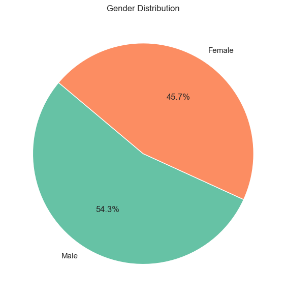

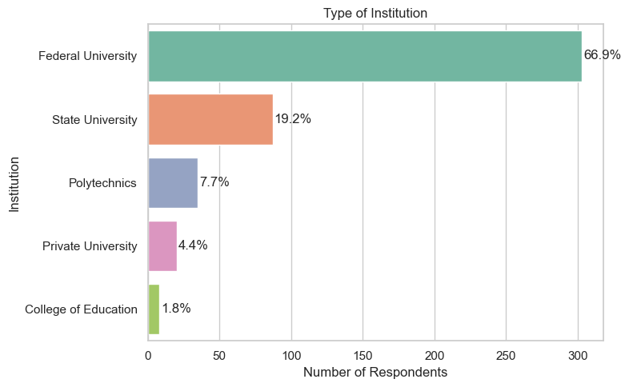

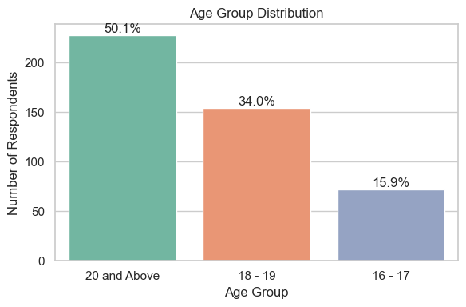

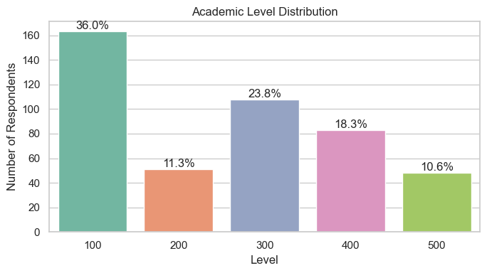

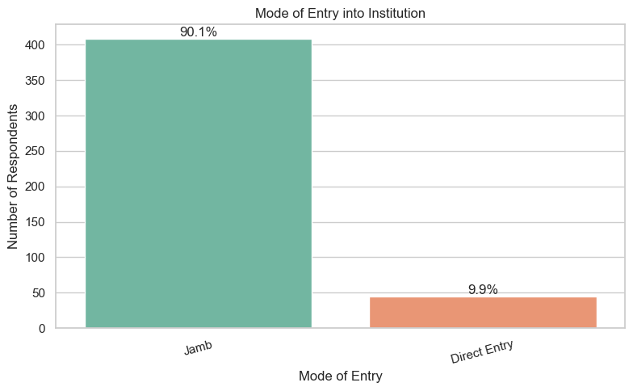

```python
warnings.filterwarnings(
    "ignore",
    message=".*The palette list has more values.*",
    category=UserWarning
)

# Set style
sns.set(style='whitegrid')
plt.rcParams.update({'font.size': 12})

# Function to add only percentage labels to bars
def add_percentage_labels(ax, total):
    for p in ax.patches:
        percentage = 100 * p.get_height() / total
        ax.annotate(f'{percentage:.1f}%',
                    (p.get_x() + p.get_width() / 2, p.get_height()),
                    ha='center', va='bottom')

# --- 1. Gender Distribution (Pie Chart)
gender_counts = df['Gender'].value_counts()
colors = sns.color_palette('Set2')[:len(gender_counts)]

plt.figure(figsize=(6,6))
plt.pie(gender_counts, labels=gender_counts.index, autopct='%1.1f%%', colors=colors, startangle=140)
plt.title('Gender Distribution')
plt.tight_layout()
plt.show()

# --- 2. Institution Type (Horizontal Bar Plot)
inst_counts = df['Institution'].value_counts()
colors = sns.color_palette('Set2', len(inst_counts))

plt.figure(figsize=(8,5))
ax = sns.barplot(x=inst_counts.values, y=inst_counts.index, palette=colors)
total = inst_counts.sum()
for i, v in enumerate(inst_counts.values):
    percentage = 100 * v / total
    ax.text(v + 1, i, f'{percentage:.1f}%', va='center')
plt.title('Type of Institution')
plt.xlabel('Number of Respondents')
plt.tight_layout()
plt.show()

# --- 3. Age Group Distribution (Bar Plot)
age_counts = df['Age_Group'].value_counts()
plt.figure(figsize=(6,4))
ax = sns.barplot(x=age_counts.index, y=age_counts.values, palette='Set2')
add_percentage_labels(ax, age_counts.sum())
plt.title('Age Group Distribution')
plt.ylabel('Number of Respondents')
plt.xlabel('Age Group')
plt.tight_layout()
plt.show()

# --- 4. Level Distribution (Ordered Bar Plot)
level_order = ['100', '200', '300', '400', '500']
df['Level'] = pd.Categorical(df['Level'], categories=level_order, ordered=True)
level_counts = df['Level'].value_counts().sort_index()

plt.figure(figsize=(7,4))
ax = sns.barplot(x=level_counts.index, y=level_counts.values, palette='Set2')
add_percentage_labels(ax, level_counts.sum())
plt.title('Academic Level Distribution')
plt.ylabel('Number of Respondents')
plt.xlabel('Level')
plt.tight_layout()
plt.show()

# --- 5. Mode of Entry Distribution (Bar Plot)
mode_counts = df['Mode_of_Entry'].value_counts()
plt.figure(figsize=(8,5))
ax = sns.barplot(x=mode_counts.index, y=mode_counts.values, palette='Set2')
add_percentage_labels(ax, mode_counts.sum())
plt.title('Mode of Entry into Institution')
plt.ylabel('Number of Respondents')
plt.xlabel('Mode of Entry')
plt.xticks(rotation=15)
plt.tight_layout()
plt.show()
```

## Academic Performance Overview

This section explores the academic outcomes of respondents, focusing on their degree classifications and how these relate to age and academic level.

The patterns suggest a clear relationship between academic maturity (age and level) and performance, reinforcing key ideas behind the study.

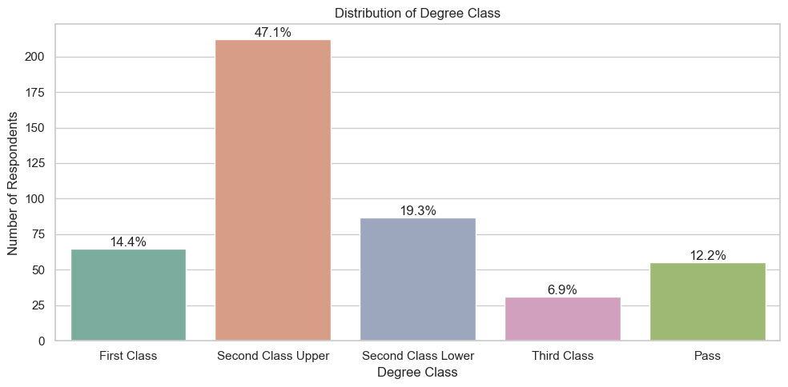

```
Degree_Class by Age_Group - Percentage (%):
 Age_Group           16 - 17  18 - 19  20 and Above
Degree_Class
First Class            9.23    27.69         63.08
Second Class Upper    14.15    37.26         48.58
Second Class Lower    13.79    32.18         54.02
Third Class           32.26    29.03         38.71
Pass                  25.45    34.55         40.00
All                   16.00    34.00         50.00
```

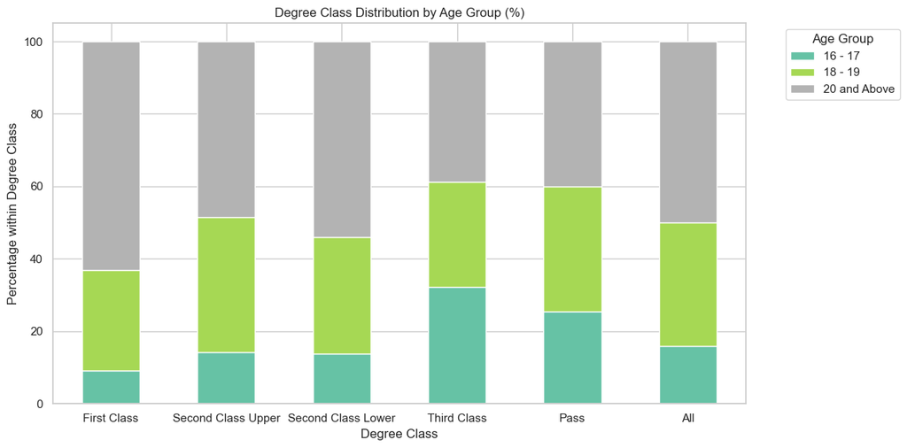

```
Cross-tab percentages of Age_Group vs Degree_Class (row-wise %):
 Degree_Class  First Class  Second Class Upper  Second Class Lower  \
Age_Group
20 and Above        18.22               45.78               20.89
18 - 19             11.76               51.63               18.30
16 - 17              8.33               41.67               16.67

Degree_Class  Third Class   Pass
Age_Group
20 and Above         5.33   9.78
18 - 19              5.88  12.42
16 - 17             13.89  19.44
```

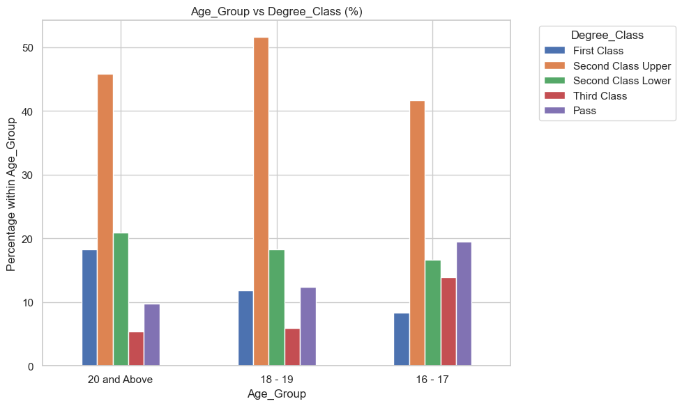

```
Degree_Class by Level - Percentage (%):
 Level                 100    200    300    400    500
Degree_Class
First Class         21.54  20.00  33.85  16.92   7.69
Second Class Upper  27.83  12.74  25.47  20.75  13.21
Second Class Lower  34.48   6.90  24.14  21.84  12.64
Third Class         70.97   3.23  16.13   9.68   0.00
Pass                63.64   7.27  10.91  10.91   7.27
All                 35.56  11.33  24.00  18.44  10.67
```

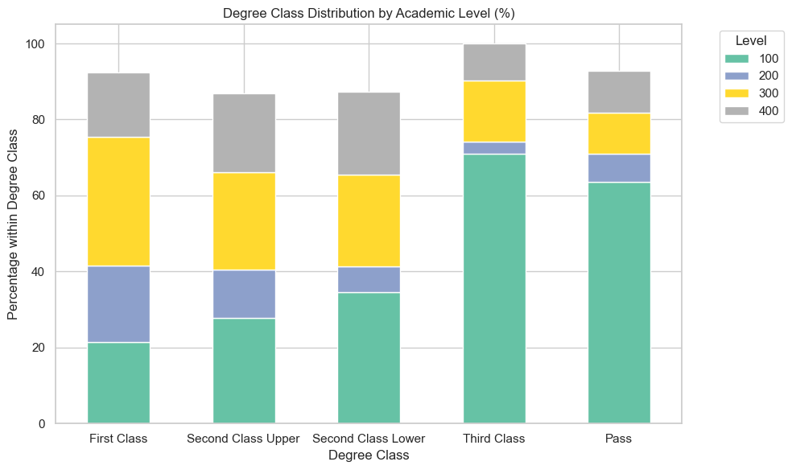

```python
# Set styles and deeper pastel palette
sns.set(style='whitegrid')
plt.rcParams.update({'font.size': 12})
deep_pastel = sns.color_palette("Set2", desat=0.7)

# Function to add percentage labels to bars
def add_pct_labels(ax, total):
    for p in ax.patches:
        height = p.get_height()
        pct = height / total * 100
        ax.annotate(f'{pct:.1f}%',
                    (p.get_x() + p.get_width() / 2, height),
                    ha='center', va='bottom')

# 1. Degree_Class bar plot with percentages
degree_order = ['First Class', 'Second Class Upper', 'Second Class Lower', 'Third Class', 'Pass']
df['Degree_Class'] = pd.Categorical(df['Degree_Class'], categories=degree_order, ordered=True)
degree_counts = df['Degree_Class'].value_counts().reindex(degree_order)

plt.figure(figsize=(10,5))
ax = sns.barplot(x=degree_counts.index, y=degree_counts.values, palette=deep_pastel)
add_pct_labels(ax, degree_counts.sum())
plt.title('Distribution of Degree Class')
plt.ylabel('Number of Respondents')
plt.xlabel('Degree Class')
plt.tight_layout()
plt.show()

# 2. Cross-tab Degree_Class by Age_Group

age_order = ['16 - 17', '18 - 19', '20 and Above']
df['Age_Group'] = pd.Categorical(df['Age_Group'], categories=age_order, ordered=True)

ct_age = pd.crosstab(df['Degree_Class'], df['Age_Group'], margins=True, normalize='index') * 100
# ct_age_counts = pd.crosstab(df['Degree_Class'], df['Age_Group'], margins=True)

print("\nDegree_Class by Age_Group - Percentage (%):\n", ct_age.round(2))

# Plot stacked bar chart for Degree_Class by Age_Group (percentage)
ct_age = ct_age[age_order]  # reorder columns explicitly

ct_age.plot(kind='bar', stacked=True, figsize=(12,6), colormap='Set2')
plt.title('Degree Class Distribution by Age Group (%)')
plt.ylabel('Percentage within Degree Class')
plt.xlabel('Degree Class')
plt.xticks(rotation=0)
plt.legend(title='Age Group', bbox_to_anchor=(1.05, 1), loc='upper left')
plt.tight_layout()
plt.show()

def plot_clustered_bar_crosstab(row_var, col_var, order=None):
    ct_counts = pd.crosstab(df[row_var], df[col_var])
    if order:
        ct_counts = ct_counts.loc[order]
    ct_pct = ct_counts.div(ct_counts.sum(axis=1), axis=0) * 100

    print(f"\nCross-tab percentages of {row_var} vs {col_var} (row-wise %):\n", ct_pct.round(2))

    # Clustered bar plot for percentages
    ct_pct.plot(kind='bar', figsize=(10,6))
    plt.title(f'{row_var} vs {col_var} (%)')
    plt.ylabel('Percentage within ' + row_var)
    plt.xlabel(row_var)
    plt.xticks(rotation=0)
    plt.legend(title=col_var, bbox_to_anchor=(1.05, 1), loc='upper left')
    plt.tight_layout()
    plt.show()


# Age_Group vs Degree_Class (ordered by degree_order)
plot_clustered_bar_crosstab('Age_Group', 'Degree_Class', order=df['Age_Group'].unique())

# 3. Cross-tab Degree_Class by Level
ct_level = pd.crosstab(df['Degree_Class'], df['Level'], margins=True, normalize='index') * 100

print("\nDegree_Class by Level - Percentage (%):\n", ct_level.round(2))

# Plot stacked bar chart for Degree_Class by Level (percentage)
ct_level_no_total = ct_level.iloc[:-1, :-1]
ct_level_no_total.plot(kind='bar', stacked=True, figsize=(10,6), colormap='Set2')
plt.title('Degree Class Distribution by Academic Level (%)')
plt.ylabel('Percentage within Degree Class')
plt.xlabel('Degree Class')
plt.xticks(rotation=0)
plt.legend(title='Level', bbox_to_anchor=(1.05, 1), loc='upper left')
plt.tight_layout()
plt.show()
```

## Perceptions and Opinions on Admission Age and Academic Readiness

This section delves into respondents' awareness of policies and their opinions on how age impacts academic performance, maturity, and readiness.

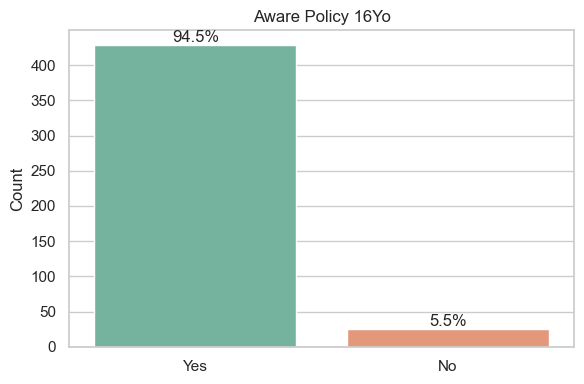

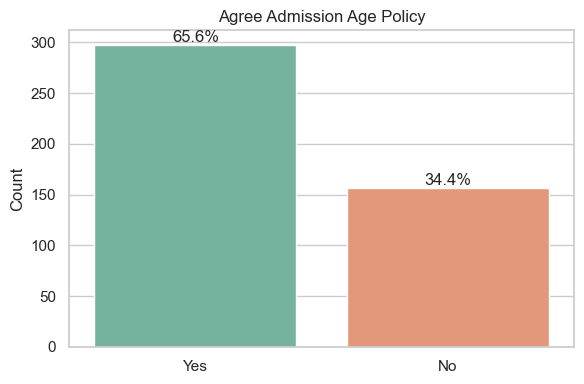

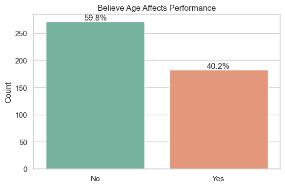

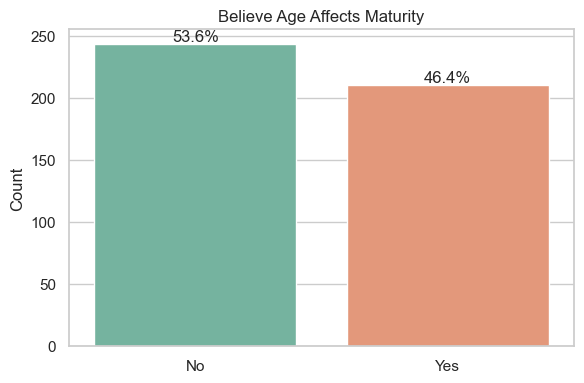

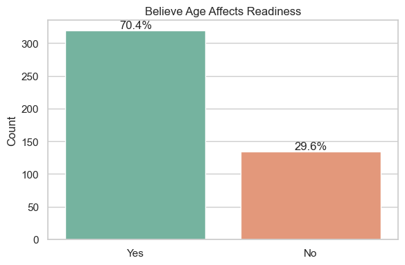

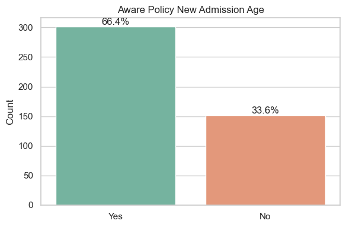

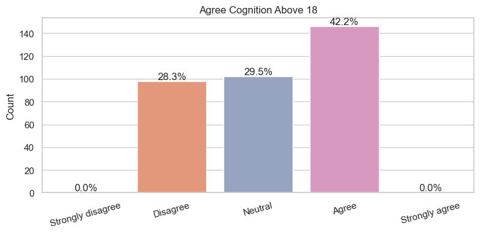

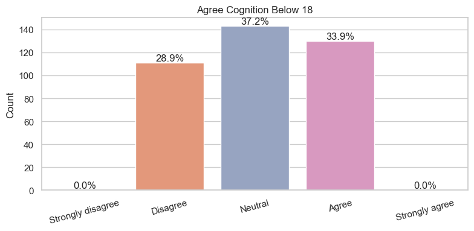

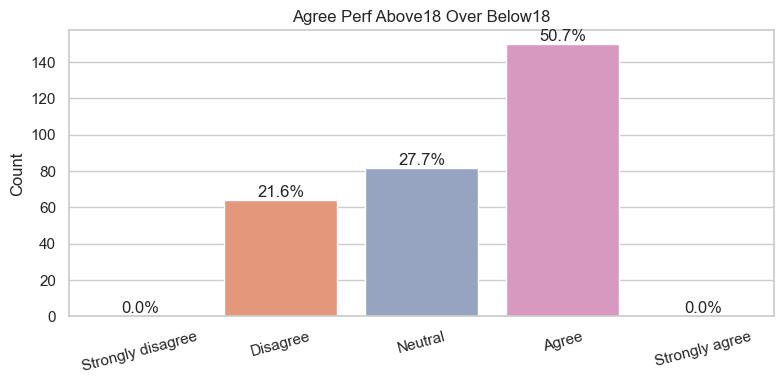

```python
# Set styles
sns.set(style='whitegrid')
plt.rcParams.update({'font.size': 12})
colors = sns.color_palette("Set2", desat=0.9)

# Function to add percentage labels
def add_pct_labels(ax, total):
    for p in ax.patches:
        height = p.get_height()
        pct = height / total * 100
        ax.annotate(f'{pct:.1f}%',
                    (p.get_x() + p.get_width() / 2, height),
                    ha='center', va='bottom')

# Yes/No columns
yes_no_cols = [
    'aware_policy_16yo', 'agree_admission_age_policy', 'believe_age_affects_performance',
    'believe_age_affects_maturity', 'believe_age_affects_readiness',
    'aware_policy_new_admission_age'
]

# Strongly Agree – Strongly Disagree scale columns
scale_cols = [
    'agree_cognition_above_18', 'agree_cognition_below_18', 'agree_perf_above18_over_below18'
]

# --- 1. Base plots and tables for Yes/No columns ---
for col in yes_no_cols:
    counts = df[col].value_counts()
    total = counts.sum()

    # Bar plot
    plt.figure(figsize=(6,4))
    ax = sns.barplot(x=counts.index, y=counts.values, palette=colors)
    add_pct_labels(ax, total)
    plt.title(col.replace('_', ' ').title())
    plt.ylabel('Count')
    plt.xlabel('')
    plt.tight_layout()
    plt.show()

# --- 2. Base plots and tables for Scale columns ---
scale_order = ['Strongly disagree', 'Disagree', 'Neutral', 'Agree', 'Strongly agree']

for col in scale_cols:
    df[col] = pd.Categorical(df[col], categories=scale_order, ordered=True)
    counts = df[col].value_counts().reindex(scale_order)
    total = counts.sum()

    # Bar plot
    plt.figure(figsize=(8,4))
    ax = sns.barplot(x=counts.index, y=counts.values, palette=colors)
    add_pct_labels(ax, total)
    plt.title(col.replace('_', ' ').title())
    plt.ylabel('Count')
    plt.xlabel('')
    plt.xticks(rotation=15)
    plt.tight_layout()
    plt.show()
```

```
--- Grouped by Age_Group ---
```

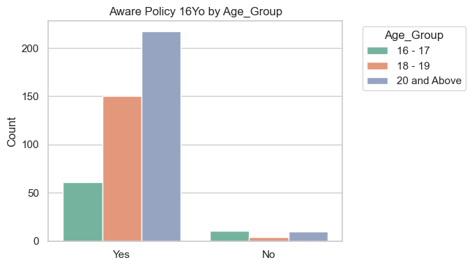

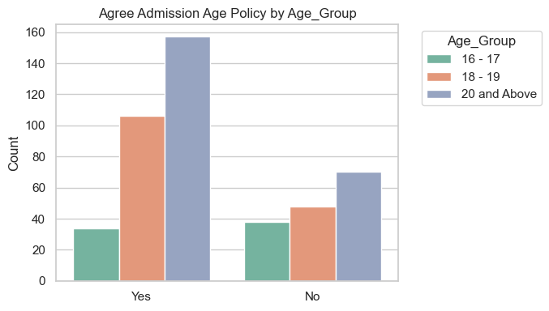

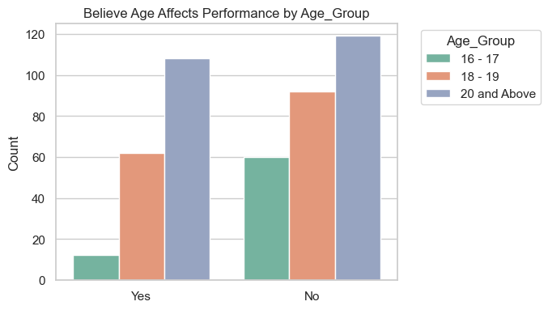

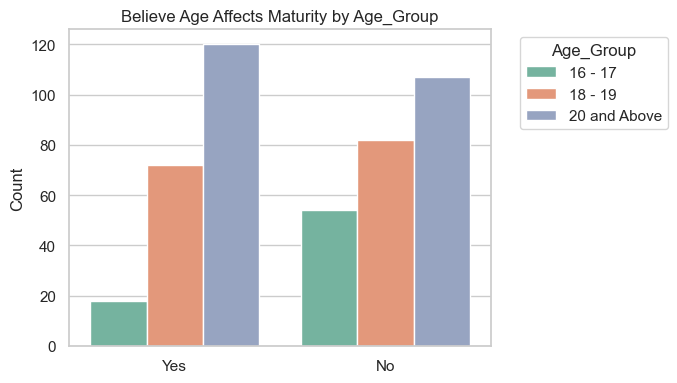

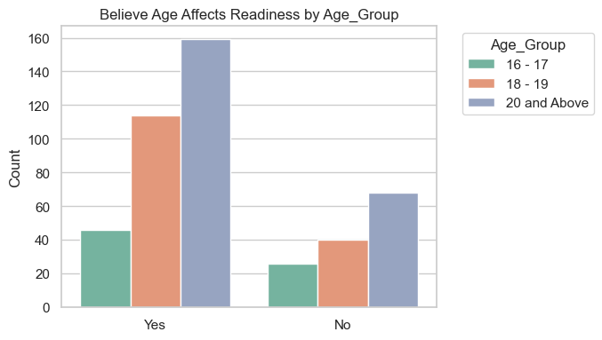

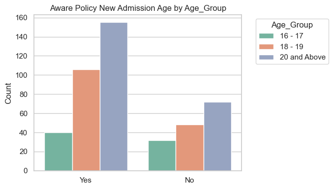

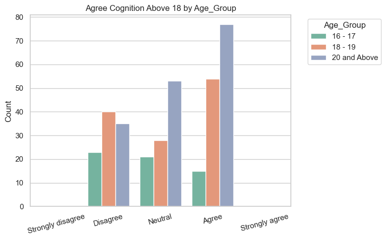

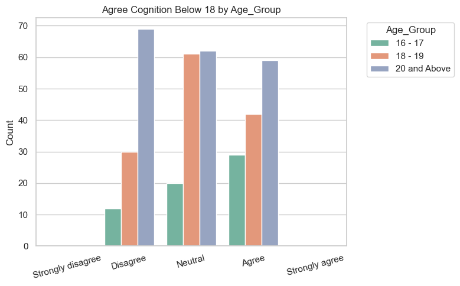

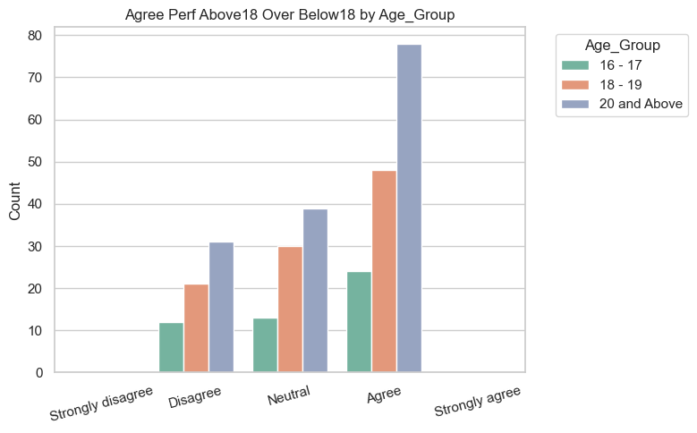

```
--- Grouped by Gender ---
```

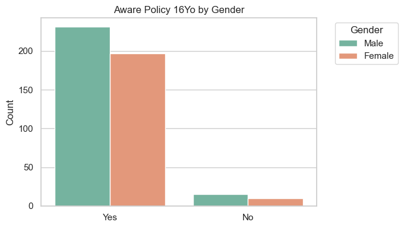

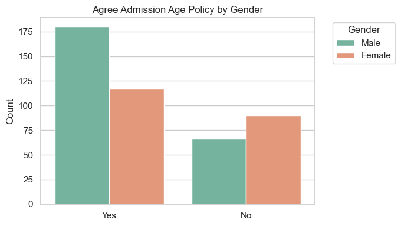

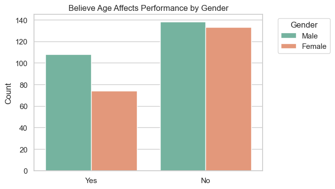

[6 more figures not shown]

```python
# --- 3. Grouped Bar Plots (by Age_Group and Gender) ---
grouping_vars = ['Age_Group', 'Gender']

for group in grouping_vars:
    print(f"\n--- Grouped by {group} ---\n")

    for col in yes_no_cols:
        plt.figure(figsize=(7,4))
        ax = sns.countplot(data=df, x=col, hue=group, palette=colors)
        plt.title(f'{col.replace("_", " ").title()} by {group}')
        plt.ylabel('Count')
        plt.xlabel('')
        plt.legend(title=group, bbox_to_anchor=(1.05, 1), loc='upper left')
        plt.tight_layout()
        plt.show()

    for col in scale_cols:
        plt.figure(figsize=(8,5))
        ax = sns.countplot(data=df, x=col, hue=group, palette=colors,
                           order=scale_order)
        plt.title(f'{col.replace("_", " ").title()} by {group}')
        plt.ylabel('Count')
        plt.xlabel('')
        plt.xticks(rotation=15)
        plt.legend(title=group, bbox_to_anchor=(1.05, 1), loc='upper left')
        plt.tight_layout()
        plt.show()
```